# Reproducible Research: Peer Assessment 1

## Loading and preprocessing the data

```r
originData<-read.csv("activity.csv")
summary(originData)
```

```
##      steps                date          interval
##  Min.   :  0.00   2012-10-01:  288   Min.   :   0.0
##  1st Qu.:  0.00   2012-10-02:  288   1st Qu.: 588.8
##  Median :  0.00   2012-10-03:  288   Median :1177.5
##  Mean   : 37.38   2012-10-04:  288   Mean   :1177.5
##  3rd Qu.: 12.00   2012-10-05:  288   3rd Qu.:1766.2
##  Max.   :806.00   2012-10-06:  288   Max.   :2355.0
##  NA's   :2304     (Other)   :15840
```

## What is mean total number of steps taken per day?

For this part of the assignment, you can ignore the missing values in the dataset.

1. Make a histogram of the total number of steps taken per day

```r
# Remove row with NA in the dataset
data<-originData[complete.cases(originData),]
summary(data)
```

```
##      steps                date          interval
##  Min.   :  0.00   2012-10-02:  288   Min.   :   0.0
##  1st Qu.:  0.00   2012-10-03:  288   1st Qu.: 588.8
##  Median :  0.00   2012-10-04:  288   Median :1177.5
##  Mean   : 37.38   2012-10-05:  288   Mean   :1177.5
##  3rd Qu.: 12.00   2012-10-06:  288   3rd Qu.:1766.2
##  Max.   :806.00   2012-10-07:  288   Max.   :2355.0
##                   (Other)   :13536
```

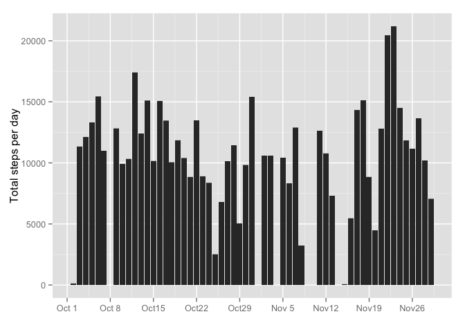

```r
#change date character to date format
data$date<-as.Date(data$date,"%Y-%m-%d")

#Make histogram
library(ggplot2)
library(scales)
g<-ggplot(data,aes(date,steps))
g+geom_histogram(stat="identity")+
        scale_x_date( labels=date_format("%b%e"),breaks = date_breaks("week"))+
        labs(x="",y="Total steps per day")
```

2. Calculate and report the mean and median total number of steps taken per day

```r
library(plyr)
StepPerDay<-ddply(data,c("date"),summarise,steps=sum(steps))
summary(StepPerDay)
```

```
##       date                steps
##  Min.   :2012-10-02   Min.   :   41
##  1st Qu.:2012-10-16   1st Qu.: 8841
##  Median :2012-10-29   Median :10765
##  Mean   :2012-10-30   Mean   :10766
##  3rd Qu.:2012-11-16   3rd Qu.:13294
##  Max.   :2012-11-29   Max.   :21194
```

The mean total number of step per day was 10766 (steps) the median was 10765 steps.

## What is the average daily activity pattern?

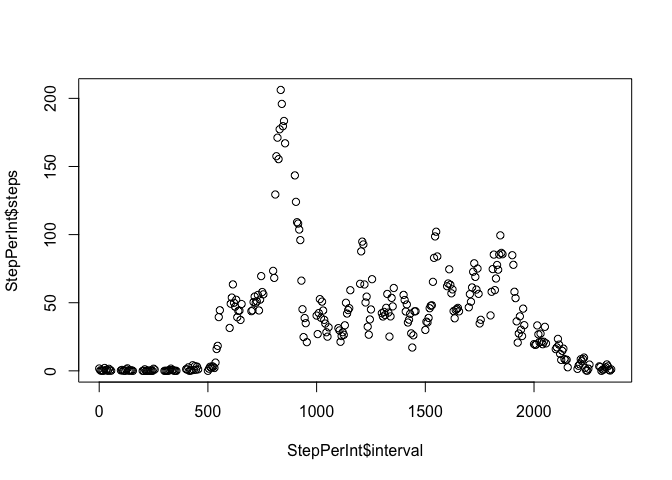

```r
StepPerInt<-ddply(data,c("interval"),summarise,steps=mean(steps))

plot(StepPerInt$interval,StepPerInt$steps)
```

The interval has maximum average of number of steps

```r
StepPerInt[StepPerInt$steps==max(StepPerInt$steps),]
```

```
##     interval    steps
## 104      835 206.1698
```

835 is the interval the maximum average of number of steps (~206 steps)

## Imputing missing values

1. I will impute the NA by average value of that interval

```r
ImpData<-originData # create a new imputed data frame
i<-1

while (i<=nrow(ImpData)){
        if (is.na(ImpData$steps[i])){
                j<-ImpData$interval[i]
                ImpData[i,1]<-StepPerInt[StepPerInt$interval==j,]$steps
        }
        i<-i+1
}
#View summary of imputed data
summary(ImpData)
```

```
##      steps                date          interval
##  Min.   :  0.00   2012-10-01:  288   Min.   :   0.0
##  1st Qu.:  0.00   2012-10-02:  288   1st Qu.: 588.8
##  Median :  0.00   2012-10-03:  288   Median :1177.5
##  Mean   : 37.38   2012-10-04:  288   Mean   :1177.5
##  3rd Qu.: 27.00   2012-10-05:  288   3rd Qu.:1766.2
##  Max.   :806.00   2012-10-06:  288   Max.   :2355.0
##                   (Other)   :15840
```

There was no NA now.

2. Make histogram of mean daily steps

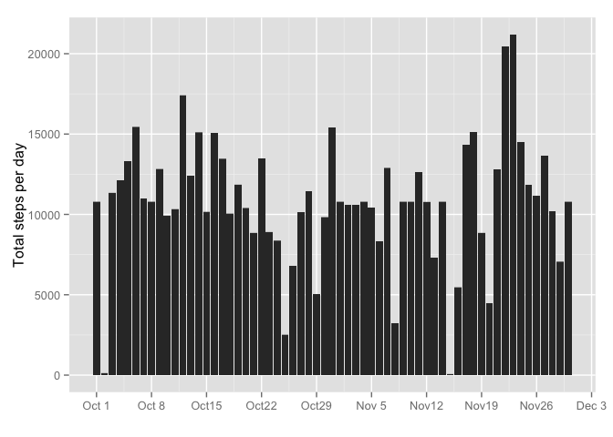

```r
#change format of character into date
ImpData$date<-as.Date(ImpData$date,format="%Y-%m-%d")

#Make histogram by using ggplot2 and scales packages
library(ggplot2)
library(scales)
his<-ggplot(ImpData,aes(date,steps))
his+geom_histogram(stat="identity")+
        scale_x_date( labels=date_format("%b%e"),breaks = date_breaks("week"))+
        labs(x="",y="Total steps per day")
```

3. Calculate the mean and median of total steps per day

```r
# Make table data
StepPerDay1<-ddply(ImpData,c("date"),summarise,steps=sum(steps))

#Caculate mean and median
summary(StepPerDay1)
```

```
##       date                steps
##  Min.   :2012-10-01   Min.   :   41
##  1st Qu.:2012-10-16   1st Qu.: 9819
##  Median :2012-10-31   Median :10766
##  Mean   :2012-10-31   Mean   :10766
##  3rd Qu.:2012-11-15   3rd Qu.:12811
##  Max.   :2012-11-30   Max.   :21194
```

We can now see that mean of total steps per day was not changed. However, median of total steps per day in imputed data has changed toward the mean value.

## Are there differences in activity patterns between weekdays and weekends?

1.Format the day to become weedays and weekends

```r
#Change date format into day
ImpData$date<-format(ImpData$date,"%a",trim=T)
table(ImpData$date) #View number of date now
```

```
##
##  Fri  Mon  Sat  Sun  Thu  Tue  Wed
## 2592 2592 2304 2304 2592 2592 2592
```

```r
#Change date to weekday and weekend
for (i in 1:nrow(ImpData)){
        ifelse(ImpData$date[i]=="Sat" | ImpData$date[i]=="Sun",
                ImpData[i,2]<-"Weekend",
               ImpData[i,2]<-"Weekday" )}

str(ImpData)
```

```
## 'data.frame':    17568 obs. of  3 variables:
##  $ steps   : num  1.717 0.3396 0.1321 0.1509 0.0755 ...
##  $ date    : chr  "Weekday" "Weekday" "Weekday" "Weekday" ...
##  $ interval: int  0 5 10 15 20 25 30 35 40 45 ...
```

2. Make graph to see steps by interval in weekday and weekend

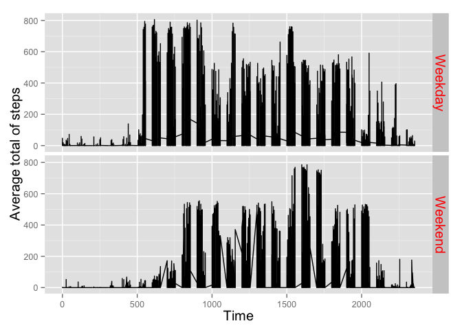

```r
library(ggplot2)
we<-ggplot(ImpData,aes(interval,steps))
we+geom_line()+facet_grid(date~.)+
        labs(x="Time",y="Average total of steps")+
        theme(strip.text.y=element_text(size=15,color="red"))+
        theme(axis.title.x=element_text(size=15))+
        theme(axis.title.y=element_text(size=15))
```

We can see that in the weekday, the high activity start earlier from 5 AM, while for the weekend, the acitivity start late at around 8 AM. after 8 AM.